# Data-Rep-Project

NICK

2024-04-06

# Hello Tony! Welcome to my data replication project

## Today, I will be replicating some figures from the nature article:

# Social trauma engages lateral septum circuitry to occlude social reward

## Before we began, it’s important for me to be honest…

## Most neuroscientist or pharmacologist do not give out well made data.frames for R, in fact, the ones from this paper gave the data for all figure parts on an excel sheet and color coordinated them

## This is not ideal for data wrangling, so I manually remade the excel sheet so it would be readable for R, I wanted to address that first

### Also, since it is just numbers in excel I am not able to determine if the data.frame I am building has the same values for the same animals, like between figure 1b and 1c, therefore, I will not be doing Figure 1e + f + j + k due to the struture being a potential nightmare to determine which mice are which. I could make assumptions but that is not scientific

```r
library(tidyverse)
```

```r
library(skimr)
#future Nick here, I tried to bring in the excel sheet, and it looked hideus...
# It looks amazing for lazy neuro data analysis but is a nightmare for this
# so this is my modified version:
d <- read.csv("https://raw.githubusercontent.com/nickmrussell/Russell-Data-Analysis-Replication/master/fig_1.csv")

head(d)
```

```
##   ID SI.Ratio Treatment sex Social_Investigation Social_Avoidance
## 1  1 0.343088       SUS   F                  132                3
## 2  2 0.652939       SUS   F                   92                7
## 3  3 0.513881       SUS   F                   85                5
## 4  4 0.396531       SUS   F                   65                3
## 5  5 0.604908       SUS   F                  120                4
## 6  6 0.577137       SUS   F                  100                3
```

```r
skim(d)
```

Data summary

| Name | d |
| --- | --- |
| Number of rows | 83 |
| Number of columns | 6 |
| _______________________ |  |
| Column type frequency: |  |
| character | 2 |
| numeric | 4 |
| ________________________ |  |
| Group variables | None |

**Variable type: character**

| skim_variable | n_missing | complete_rate | min | max | empty | n_unique | whitespace |
| --- | --- | --- | --- | --- | --- | --- | --- |
| Treatment | 0 | 1 | 3 | 4 | 0 | 3 | 0 |
| sex | 0 | 1 | 1 | 1 | 0 | 2 | 0 |

**Variable type: numeric**

| skim_variable | n_missing | complete_rate | mean | sd | p0 | p25 | p50 | p75 | p100 | hist |
| --- | --- | --- | --- | --- | --- | --- | --- | --- | --- | --- |
| ID | 0 | 1 | 42.00 | 24.10 | 1.00 | 21.50 | 42.00 | 62.5 | 83.00 | ▇▇▇▇▇ |
| SI.Ratio | 0 | 1 | 0.99 | 0.57 | 0.07 | 0.59 | 0.92 | 1.2 | 3.28 | ▆▇▂▁▁ |
| Social_Investigation | 0 | 1 | 107.42 | 40.58 | 30.00 | 85.50 | 106.00 | 130.5 | 215.00 | ▅▆▇▁▂ |
| Social_Avoidance | 0 | 1 | 5.37 | 7.53 | 0.00 | 0.00 | 3.00 | 7.0 | 35.00 | ▇▁▁▁▁ |

### They do not do descriptive statistics directly in the paper, so here is their means and sd’s. I don’t break it down by sex here but we will in the figures

# Figure 1 shows a decrease in social activity in susceptable (meaning that their neuronal physiology in the population stated above is altered) male and female mice experience long-term social stress in the form of social defeat

# Figure 1b: Decrease in social interaction between a mouse and an object found in susceptable mice

```r
# Filtering the data for only the ladies
f <- d %>% filter(sex == "F")
# Figure 1b, social interaction ratio by group via one-way ANOVA
a1 <- aov(data = f, SI.Ratio ~ as.factor(Treatment))

g <- ggplot(f, aes(x = SI.Ratio, y = as.factor(Treatment), fill = as.factor(Treatment)))
g <- g +  geom_bar(stat = "summary", show.legend = FALSE)
g <- g + scale_fill_manual(values = c("darkgrey", "red", "lightgrey"))
g <- g + theme_classic() + geom_point() + xlim(0, 2.5) + theme(axis.title.y=element_blank(), legend.position = "none") + scale_x_continuous(expand = c(0,0), limits = c(0,2.5))
summary(a1)
```

```
##                      Df Sum Sq Mean Sq F value   Pr(>F)
## as.factor(Treatment)  2  4.117  2.0586   53.96 8.01e-11 ***
## Residuals            31  1.183  0.0382
## ---
## Signif. codes:  0 '***' 0.001 '**' 0.01 '*' 0.05 '.' 0.1 ' ' 1
```

```r
TukeyHSD(a1)
```

```
##   Tukey multiple comparisons of means
##     95% family-wise confidence level
##
## Fit: aov(formula = SI.Ratio ~ as.factor(Treatment), data = f)
##
## $`as.factor(Treatment)`
##                diff        lwr        upr     p adj
## RES-Ctrl  0.1582172 -0.0476254  0.3640598 0.1579852
## SUS-Ctrl -0.6297101 -0.8355527 -0.4238676 0.0000001
## SUS-RES  -0.7879273 -0.9841905 -0.5916641 0.0000000
```

```r
print(g)
```

```
## No summary function supplied, defaulting to `mean_se()`
```

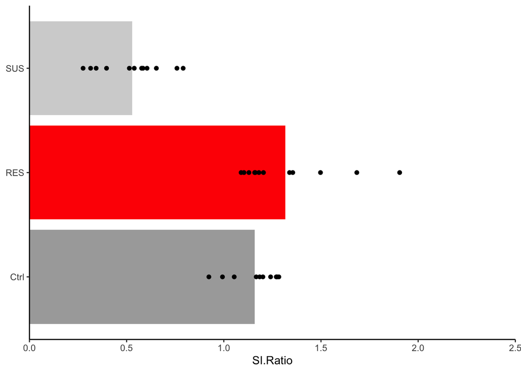

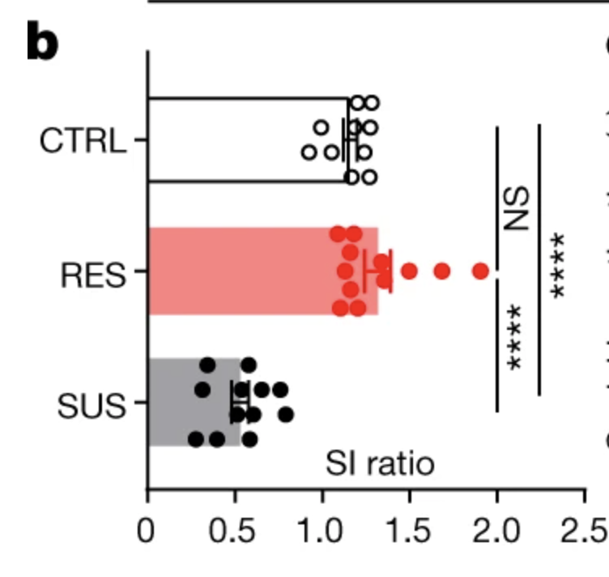

### After running the ANOVA, the F-statistic lines up with the paper exactly! (F(2, 31) = 53.96) and the paper just stated it was a very significant p value (p < 0.0001) (which is Dr. Russo flexing on me and the rest of the social stress community) which matches with the extremely low p-value we found above.

### The post hoc analysis also shows significance of p < 0.0001 in RES vs. SUS and CTRL vs. SUS which matches what is found in the paper.

### There seems to be more spread in the figure 1b graph than in the publication, I am unsure as to why, it could be due to the differences in GraphPag and ggplot but that additional variation is interesting and will be reccouring so keep an eye out.

# Figure 1c: Female mice that are susceptable to social stress spend less time investigating the novel mouse

```r
# Fig. 1c: amount of time in seconds spent socially investigating
a2 <- aov(data = f, Social_Investigation ~ as.factor(Treatment))
# Followed by a Tukey multiple-comparisions test


g <- ggplot(f, aes(x = as.factor(Treatment), y = Social_Investigation, fill = as.factor(Treatment)))
g <- g +  geom_bar(stat = "summary", show.legend = FALSE)
g <- g + scale_fill_manual(values = c("lightgrey", "red", "darkgrey"))
g <- g + theme_classic() +  geom_point() + theme(axis.title.x=element_blank(), legend.position = "none") + labs( y = "Social Investigation (s)") + ylim(0, 200) + scale_y_continuous(expand = c(0,0), limits = c(0,200))
summary(a2)
```

```
##                      Df Sum Sq Mean Sq F value  Pr(>F)
## as.factor(Treatment)  2   8597    4298   6.755 0.00367 **
## Residuals            31  19727     636
## ---
## Signif. codes:  0 '***' 0.001 '**' 0.01 '*' 0.05 '.' 0.1 ' ' 1
```

```r
TukeyHSD(a2)
```

```
##   Tukey multiple comparisons of means
##     95% family-wise confidence level
##
## Fit: aov(formula = Social_Investigation ~ as.factor(Treatment), data = f)
##
## $`as.factor(Treatment)`
##                diff       lwr         upr     p adj
## RES-Ctrl   9.333333 -17.25030  35.9169715 0.6665468
## SUS-Ctrl -27.250000 -53.83364  -0.6663618 0.0436194
## SUS-RES  -36.583333 -61.92984 -11.2368289 0.0034687
```

```r
print(g)
```

```
## No summary function supplied, defaulting to `mean_se()`
```

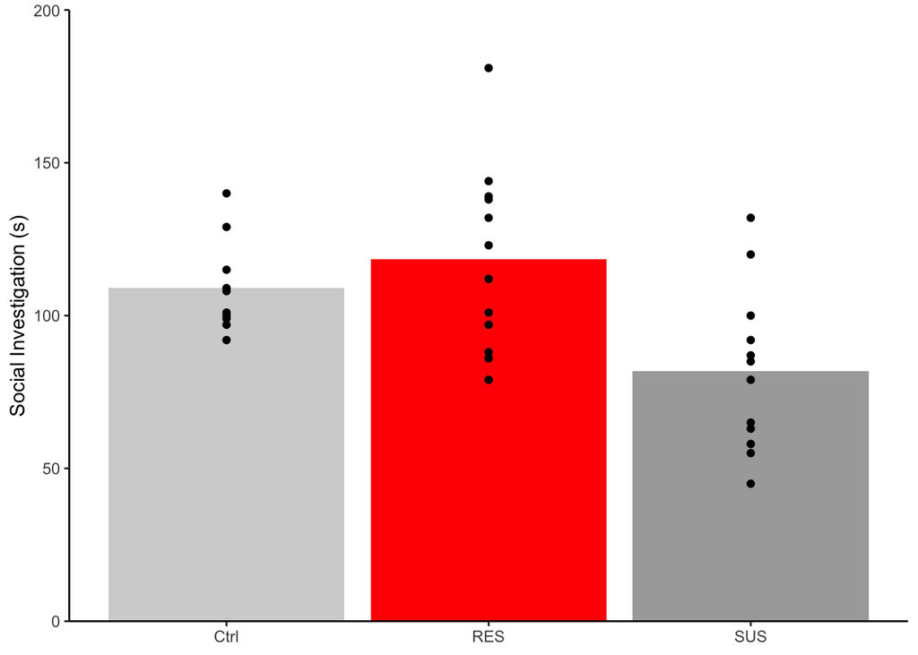

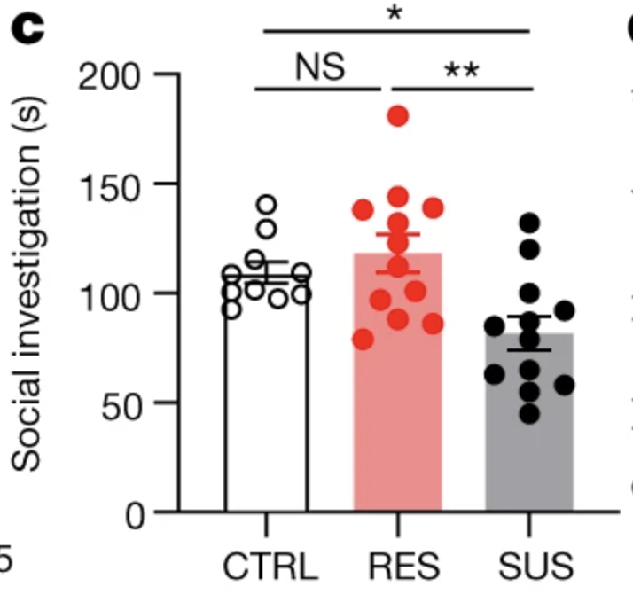

### The F statistic and p-value was still identical to the paper: f-stat = 6.755 and p-value = 0.00367.

### For Post-hoc, they provide just astricks to represent significance in the figure. It matches up with what is provided my version:

### SUS vs. CRTL: p = 0.043, SUS vs. RES: p = 0.003.

### This is actually impressive how identical it is so far.

# Figure 1d: Amount of social avoidance each group of female mice had

```r
# Fig. 1d: still female data, but its the count of times the mouse socially avoided the novel mouse
a3 <- aov(data = f, Social_Avoidance ~ as.factor(Treatment))

# Followed by a Tukey multiple-comparisions test
g <- ggplot(f, aes(x = as.factor(Treatment), y = Social_Avoidance, fill = as.factor(Treatment)))
g <- g +  geom_bar(stat = "summary", show.legend = FALSE)
g <- g + scale_fill_manual(values = c("lightgrey", "red", "darkgrey"))
g <- g + theme_classic() +  geom_point() + theme(axis.title.x=element_blank(), legend.position = "none") + labs( y = "Social Avoidance (count)") + ylim(0, 10) + scale_y_continuous(expand = c(0,0), limits = c(0,10))
summary(a3)
```

```
##                      Df Sum Sq Mean Sq F value   Pr(>F)
## as.factor(Treatment)  2 112.71   56.35   33.13 2.01e-08 ***
## Residuals            31  52.73    1.70
## ---
## Signif. codes:  0 '***' 0.001 '**' 0.01 '*' 0.05 '.' 0.1 ' ' 1
```

```r
TukeyHSD(a3)
```

```
##   Tukey multiple comparisons of means
##     95% family-wise confidence level
##
## Fit: aov(formula = Social_Avoidance ~ as.factor(Treatment), data = f)
##
## $`as.factor(Treatment)`
##              diff       lwr      upr    p adj
## RES-Ctrl 1.816667 0.4422215 3.191112 0.007549
## SUS-Ctrl 4.483333 3.1088881 5.857779 0.000000
## SUS-RES  2.666667 1.3561846 3.977149 0.000061
```

```r
print(g)
```

```
## No summary function supplied, defaulting to `mean_se()`
```

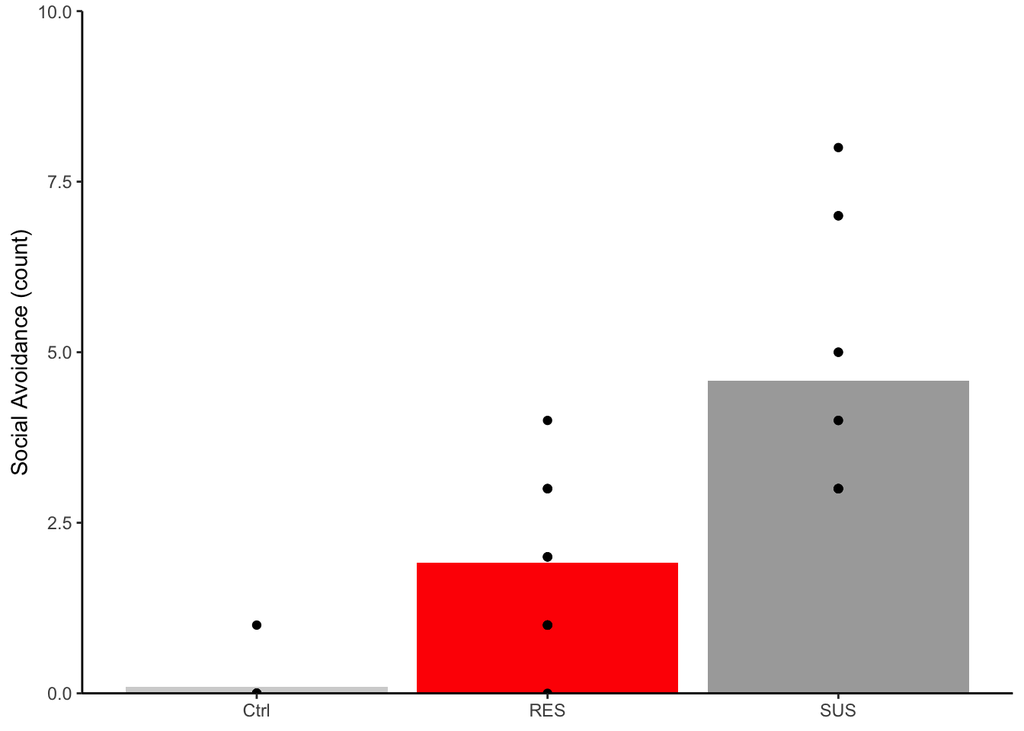

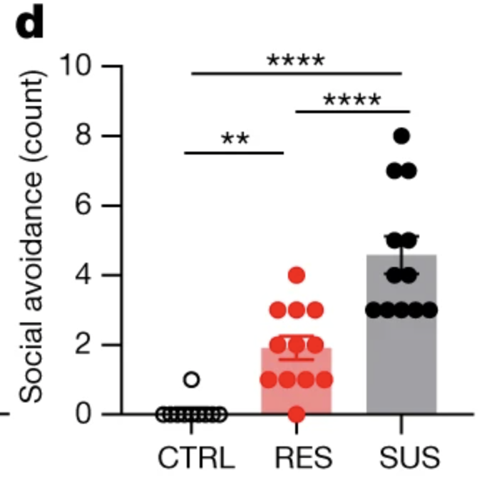

### And post-hoc matches with significances between all the groups, suprisingly indicating that the resistant group has a higher level of resistance compared to the control group despite the other metrics not indicating this difference.

# Figure 1g, h, & i

# Figure 1g: The social interaction ratio in male mice, similar to Fig. 1b

```r
# Filtering for the fellas
m <- d %>% filter(sex == "M")
# Figure 1b, social interaction ratio by group via one-way ANOVA
a4 <- aov(data = m, SI.Ratio ~ as.factor(Treatment))
g <- ggplot(m, aes(x = SI.Ratio, y = as.factor(Treatment), fill = as.factor(Treatment)))
g <- g +  geom_bar(stat = "summary")
g <- g + scale_fill_manual(values = c("darkgrey", "red", "lightgrey"))
g <- g + theme_classic() +  geom_point() + xlim(0, 4) + theme(axis.title.y=element_blank(), legend.position = "none") + scale_x_continuous(expand = c(0,0), limits = c(0,4))
summary(a4)
```

```
##                      Df Sum Sq Mean Sq F value  Pr(>F)
## as.factor(Treatment)  2  10.78   5.390   24.36 6.1e-08 ***
## Residuals            46  10.18   0.221
## ---
## Signif. codes:  0 '***' 0.001 '**' 0.01 '*' 0.05 '.' 0.1 ' ' 1
```

```r
TukeyHSD(a4)
```

```
##   Tukey multiple comparisons of means
##     95% family-wise confidence level
##
## Fit: aov(formula = SI.Ratio ~ as.factor(Treatment), data = m)
##
## $`as.factor(Treatment)`
##                diff        lwr        upr     p adj
## RES-Ctrl  0.3395073 -0.1396544  0.8186689 0.2101709
## SUS-Ctrl -0.7190882 -1.1429794 -0.2951971 0.0004682
## SUS-RES  -1.0585955 -1.4455534 -0.6716376 0.0000001
```

```r
print(g)
```

```
## No summary function supplied, defaulting to `mean_se()`
```

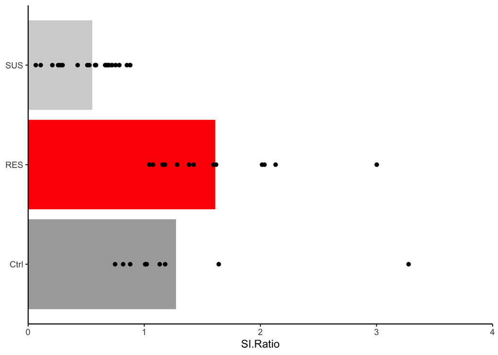

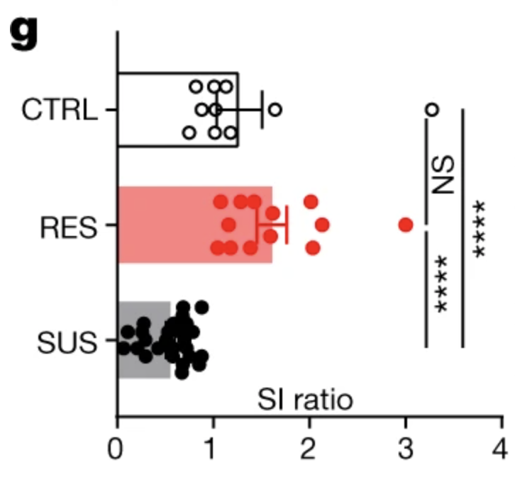

### So now we start to see the male data ### The F-stastic is the same (F-stat (2, 46) = 24.36) and the p value is still the same amount of significant:p < 0.0001. ### The posthoc astricks actually dampen the signficant differences with them both being the same but it is acutally: ### SUS vs. CRTL: p = 0.00046, SUS vs. RES: p = 0.0000001.